# Lecture 08

## A better use of facet_grid

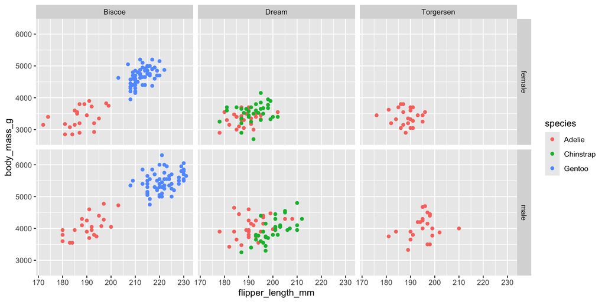

```r
ggplot(data = my_penguins,
       aes(x = flipper_length_mm,
           y = body_mass_g)) +
  geom_point(aes(color = species)) +
  facet_grid(sex ~ island)
```

## Statistics - depends on the geom

- Some of the geoms automatically apply a statistical transformation to the data, we need to do little except call them:

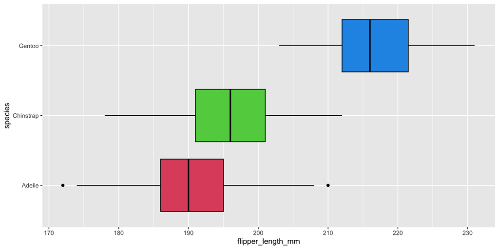

```r
ggplot(data = my_penguins,
       aes(x = flipper_length_mm,
           y = species)) +
  geom_boxplot(color = "black", fill = 2:4)
```

## Statistics - histogram

- But others require additional work on our part

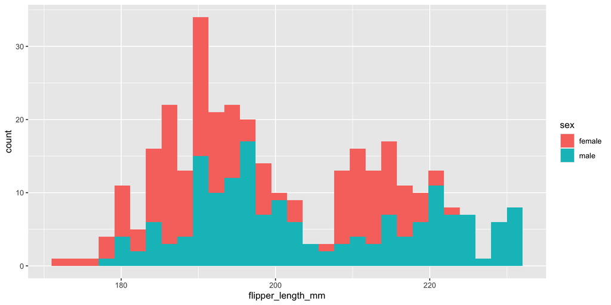

```r
ggplot(data = my_penguins,
       aes(x = flipper_length_mm, fill = sex)) +
  geom_histogram()
```

## Statistics - histogram modified

- Notice, the modifications go in the geom_ because they are appearance changes, not fundamental structural changes that the aes() addresses

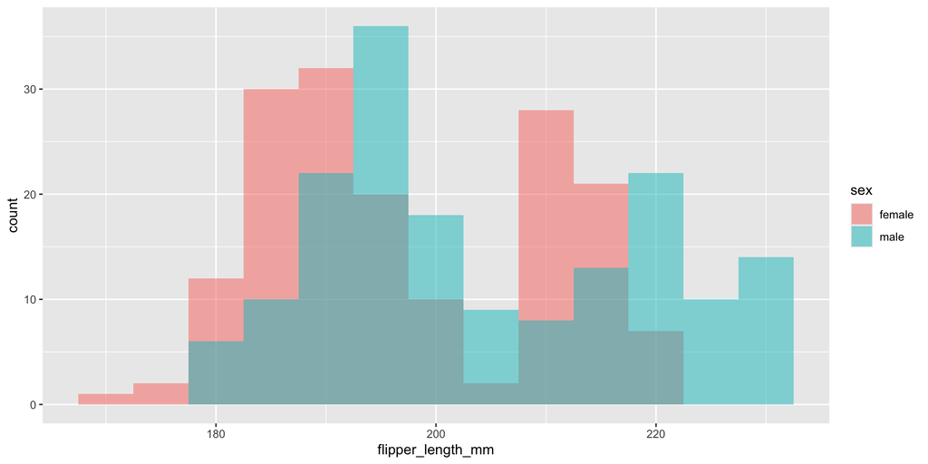

```r
ggplot(data = my_penguins,
       aes(x = flipper_length_mm, fill = sex)) +
  geom_histogram(position = "identity",
                 binwidth = 5,
                 alpha = 0.5)
```

## Scales

- scales could be use to specify color

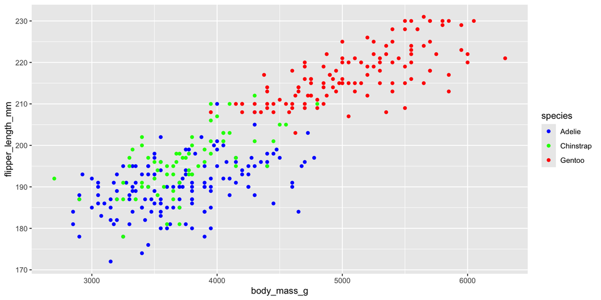

```r
ggplot(my_penguins,
       aes(x = body_mass_g,
           y = flipper_length_mm,
           color = species)) +
  geom_point() +
  scale_color_manual(values = c("Adelie" = "blue",
                                "Chinstrap" = "green",
                                "Gentoo" = "red"))
```

## More Scales

- but usually used to transform the data

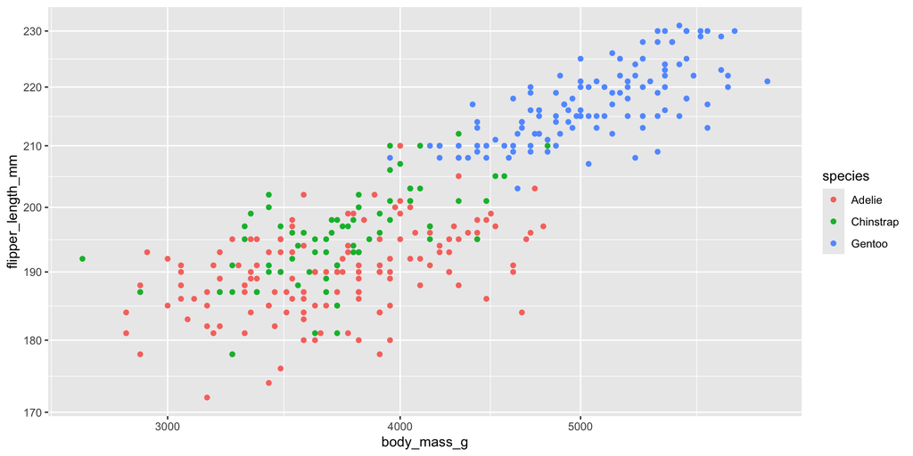

```r
ggplot(my_penguins, aes(x = body_mass_g, y = flipper_length_mm)) +
  geom_point(aes(color = species)) +
  scale_x_log10() +
  scale_y_log10()
```

## Saving a plot as an object

- We can create a gpplot and store it in an object and then modify it with different coordinate systems, this is a powerful feature of ggplot
- Coordinates can be flipped, which is useful for bar charts when you have long category names or many categories

```r
# ggplot(my_penguins, aes(y = island, fill = island)) + geom_bar()
p <- ggplot(my_penguins, aes(x = species, fill = species)) +
  geom_bar()
```

- Nothing shows…

## Saved Plot revealed

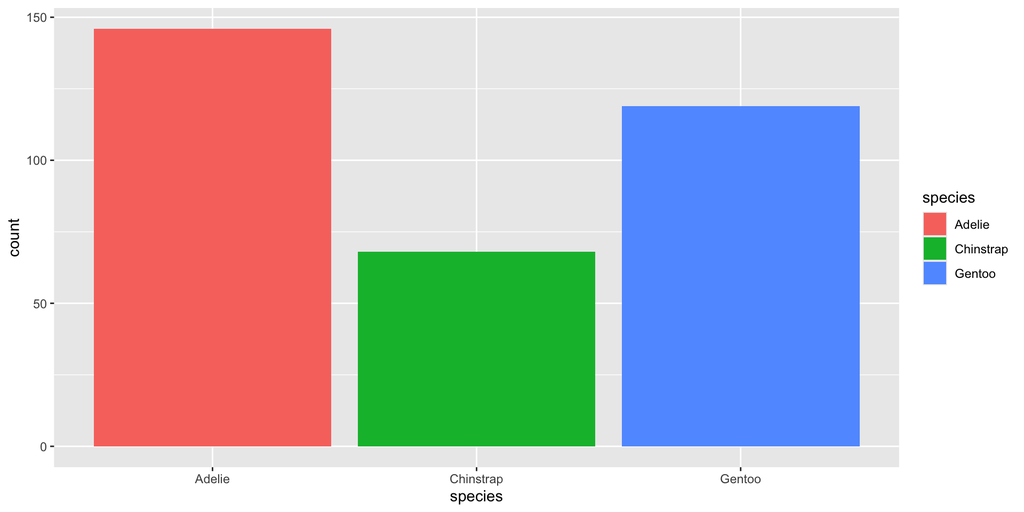

```r
p
```

## Saved Plot modified

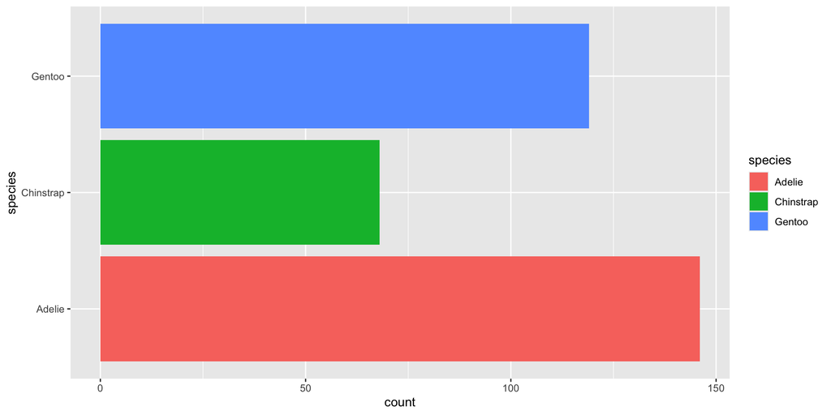

```r
p + coord_flip()
```

## Also Polar coodinates

- could use more categories, but hopefully you see how easy this is to do with ggplot

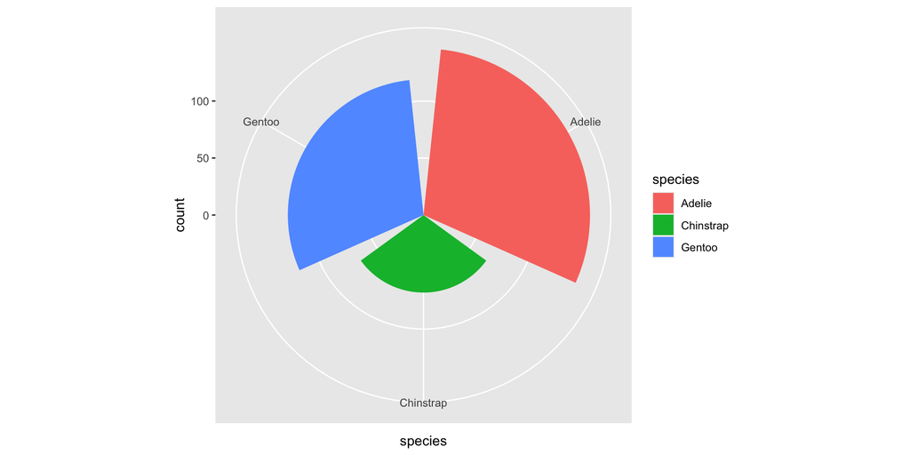

```r
p + coord_polar()
```

## aside: in base R

- Not as flexible as ggplot, but you can do this in base R (extra work)
- ggplot is just a tool that makes things easier

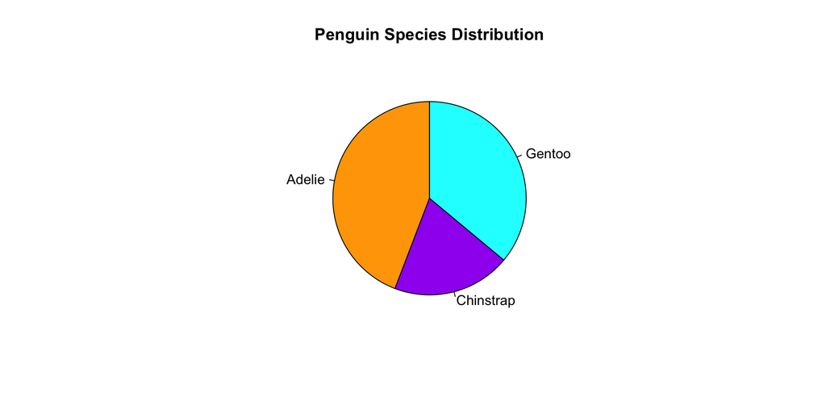

```r
# 1. Pre-calculate the bar height (remember: barplot is not smart)
counts <- table(penguins$species)

# 2. Setup colors to match the 'fill' logic
palette <- c("Adelie" = "orange", "Chinstrap" = "purple", "Gentoo" = "cyan")

# 3. Create the plot
# Base R's pie() is the closest thing to coord_polar() + geom_bar()
pie(counts,
    col = palette[names(counts)],
    main = "Penguin Species Distribution",
    init.angle = 90) # Adjusting the start point
```

## Themes

The remaining functions of ggplot deal with appearance such as labels, legends, tick marks, background color etc. etc.

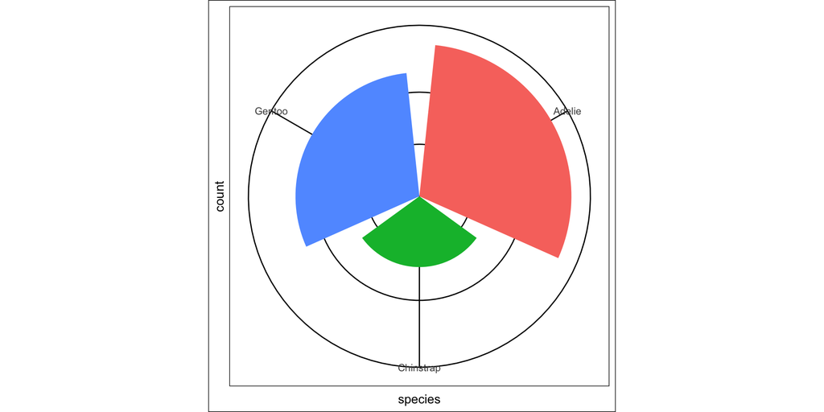

```r
p + coord_polar() +
  theme(
    legend.position = "none",
    axis.text.y = element_blank(),
    axis.ticks = element_blank(),
    panel.background = element_rect(fill = "white", colour = "black"),
    panel.grid.major = element_line(colour = "black"),
    panel.grid.minor = element_blank(),
    plot.background = element_rect(fill = "white", colour = "black")
  )
```

## Takeaways

- All of these functions are just tools
- There are so many graphical functions and options for them that it is a bit overwhelming.
- What will help is to have a clear idea of the message or story that you wish to tell
- That helps you decide which data visualization is most suitable for your needs